# De novo motif discovery with *rGADEM*,

Jim Zhang

2019-08-31

**Introduction**

This analysis performs the main functionality of Bioconductor package **rGADEM** to discover de novo motif(s) over-represented in a set of DNA sequences. Please read the package [manual](https://www.bioconductor.org/packages/devel/bioc/vignettes/rGADEM/inst/doc/rGADEM.pdf) first for background about **GADEM** algorithm and how to choose its parameters.

The set of DNA sequences, within which de novo motifs and their position weighted matrix (PWM) will be discovered, can be provided as a named character vector, an *DNAStringSet* object, or a set of genomic loci within a reference genome, such as *[BSgenome.Hsapiens.NCBI.GRCh38](http://bioconductor.org/packages/release/data/annotation/html/BSgenome.Hsapiens.NCBI.GRCh38.html)*.

This analysis includes three major steps:

1. The *GADEM {rGADEM}* is called using given parameters to discover over-presented de novo motifs from a set of DNA sequences.
2. The motifs and their matches in the DNA sequences are summarized and visualized.
3. The motifs are searched again within the DNA sequences using the *matchPWM {Biostrings}* function and a p value cutoff, to identify report all matches and their matching scores.

*[Go to project home](https://github.com/zhezhangsh/RoCA)*

# 1 Description

## 1.1 Project

rGADAM wrapper

## 1.2 Analysis

Search for DNA motifs around TSS of a few random genes.

*[Go to project home](https://github.com/zhezhangsh/RoCA)*

# 2 Results

## 2.1 Summarize sequences

**GADEM** discovers de novo motifs in a given set of DNA sequences. The length, number, base frequency, and complexity of the sequences could all impact the output of GADEM, such as the specificity of motifs and the significance of matches. It’s preferable to exclude outliers from the analysis, and strong overall bias of any characteristics could be a concern for follow-up analysis.

**81** sequences are analyzed by the *GADEM {rGADEM}* function to discover de novo motifs, using the following parameters:

- Seed PWM: *Spwm* = no
- Number of EM step: *numEM* = 80
- P value cutoff of matches: *pValue* = 2e-04
- Mask low-complexity sequences: *maskR* = yes
- Maximal number of motifs allowed: *nmotifs* = 25

**Table 1.** Summary of DNA sequences.

- *Length (bp)*: full length of DNA sequences
- *GC (%)*: frequency of G and C
- *CpG (%)*: frequency of CG or GC sites
- *Duplex (%)*: frequency of duplexes (AA, CC, GG, or TT)

Click here to view details of individual sequences.

|  | Min. | 1st Qu. | Median | Mean | 3rd Qu. | Max. |
| --- | --- | --- | --- | --- | --- | --- |
| Length (bp) | 201.00 | 201.00 | 201.00 | 201.00 | 201.00 | 201.00 |
| GC (%) | 25.87 | 46.27 | 56.22 | 56.88 | 69.65 | 86.57 |
| CpG (%) | 1.50 | 7.00 | 12.00 | 14.51 | 22.00 | 34.50 |
| Duplex (%) | 20.00 | 27.50 | 31.00 | 31.16 | 34.00 | 49.00 |

*[Go to project home](https://github.com/zhezhangsh/RoCA)*

## 2.2 Discover motifs

**GADEM** is run using given parameters to discover motifs from DNA sequences. It reports the consensus sequence and PWM of each motif, as well as the most significant matches that the consensus and PWM are based upon.

**Table 2.** Summary of motifs found from sequences. Click motif name to see full list of matches to each motif and their details. Click consensus sequence to see its PWM.

- *GC (%):* average GC frequency at all position in PWM.
- *Num_Base:* length of the motif.
- *Num_Match:* total number of matches to the motif reported by GADEM in any sequences.
- *Num_Seq:* number of sequences including one or more matches to the motif
- *RevComp (%):* percent of matches on the reversed direction

| Name | Consensus | GC (%) | Num_Base | Num_Match | Num_Seq | RevComp (%) |
| --- | --- | --- | --- | --- | --- | --- |
| Motif_1 | sCCCsCsCCkCysCCnCCCn | 81.16 | 20 | 68 | 39 | 55.9 |
| Motif_2 | nTTTdTwAAwswnwwrnywrA | 27.98 | 21 | 45 | 29 | 40.0 |
| Motif_3 | ssyynCmnmrTCTrGrAwGTGAGGAGCsksTCykC | 58.26 | 35 | 12 | 7 | 0.0 |

PWM Logo

Matching position

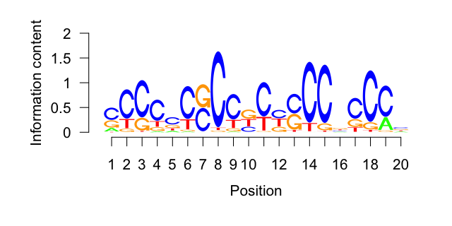

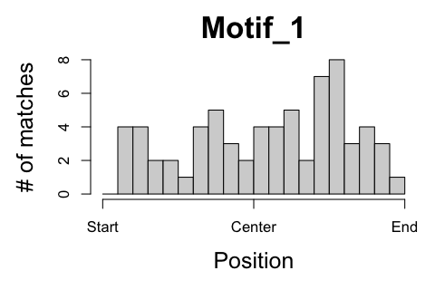

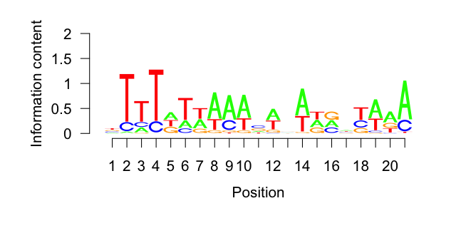

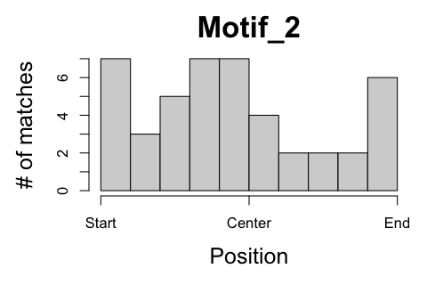

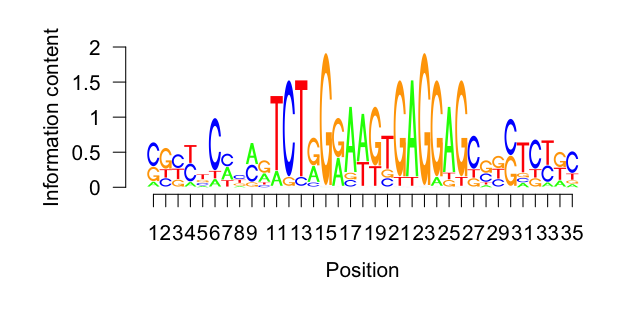

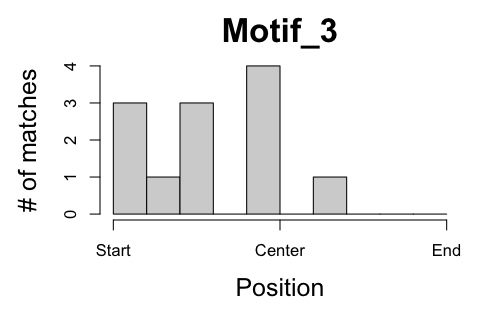

*[Go to project home](https://github.com/zhezhangsh/RoCA)*

## 2.3 Search motifs

The following steps are applied to identify more matches to the motifs discovered by **GADEM** and properly evaluate their significance:

- Calculate overall base frequency in all DNA sequences.
- For each motif, draw 100000 random sequences if the same length based on overall base frequency.
- Get the background distribution of matching scores based on the agreement between all random sequences and the motif.
- Obtain a cutoff matching score based on the background distribution with an empirical p value less than 0.005
- Search and report matches to the motif in DNA sequences using the cutoff matching score, using the ***matchPWM {Biostrings}** function.

**Table 3.** Summary of matches to the motifs:

- *Motif:* nanme of motifs, click to view full list of matches
- *Len_Motif:* length of motifs
- *Match_Per_Kb:* number of matches in each kilobase of DNA sequences
- *Num_Match:* total number of matches
- *Num_Seq:* number of sequences containing one or more matches
- *RevComp (%):* percent of matches on the opposite direction
- *Min_Score, Mean_Score, Max_Score:* range of matching scores (0 - 100)

| Motif | Len_Motif | Match_Per_Kb | Num_Match | Num_Seq | RevComp (%) | Min_Score | Mean_Score | Max_Score |
| --- | --- | --- | --- | --- | --- | --- | --- | --- |
| Motif_1 | 20 | 11.664 | 171 | 58 | 58.48 | 67.0 | 76.72 | 93.8 |
| Motif_2 | 21 | 10.082 | 147 | 57 | 46.26 | 66.1 | 74.06 | 92.9 |
| Motif_3 | 35 | 8.181 | 110 | 62 | 51.82 | 57.3 | 62.82 | 98.8 |

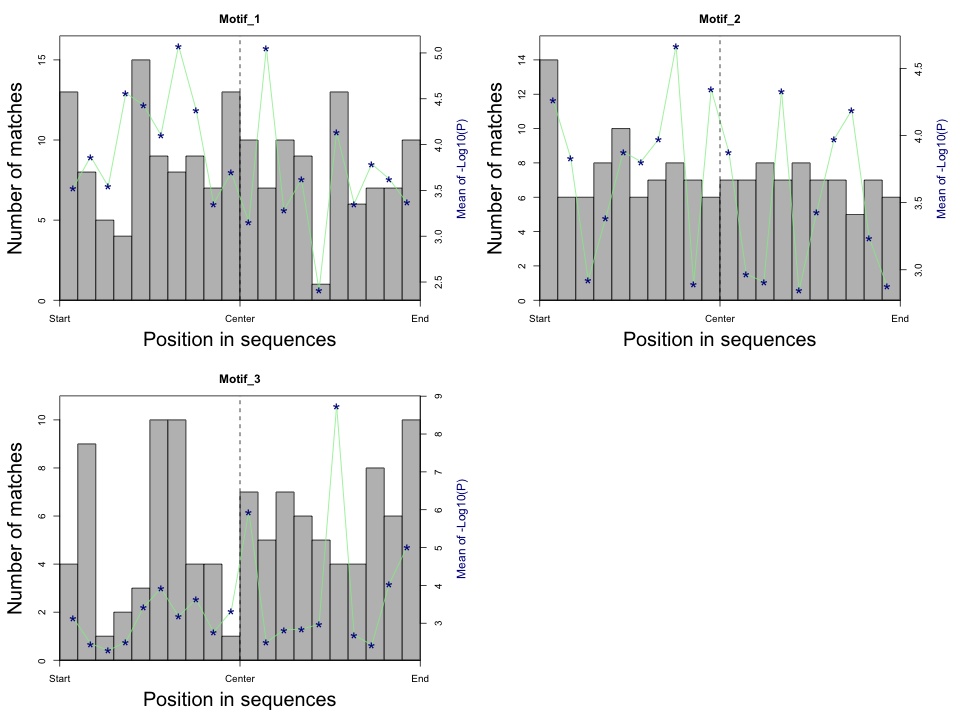

**Figure 2.** Distribution of relative positions of motif matches within the DNA sequences. Grey bar is the number of matches within each 5% interval and blue star is the average Phred score (-log10 transformed p value) of matches within the interval.

*[Go to project home](https://github.com/zhezhangsh/RoCA)*

# 3 Download

- **Motif_1:** PWM **|** GADEM hits **|** All matches
- **Motif_2:** PWM **|** GADEM hits **|** All matches
- **Motif_3:** PWM **|** GADEM hits **|** All matches

# 4 Appendix

Check out the **[RoCA home page](http://zhezhangsh.github.io/RoCA)** for more information.

## 4.1 Reproduce this report

To reproduce this report:

1. Find the data analysis template you want to use and an example of its pairing YAML file [here](https://github.com/zhezhangsh/RoCA/wiki/Templates-and-examples) and download the YAML example to your working directory
2. To generate a new report using your own input data and parameter, edit the following items in the YAML file:
   - *output* : where you want to put the output files
   - *home* : the URL if you have a home page for your project
   - *analyst* : your name
   - *description* : background information about your project, analysis, etc.
   - *input* : where are your input data, read instruction for preparing them
   - *parameter* : parameters for this analysis; read instruction about how to prepare input data
3. Run the code below within *R Console* or *RStudio*, preferablly with a new R session:

```r
if (!require(devtools)) { install.packages('devtools'); require(devtools); }
if (!require(RCurl)) { install.packages('RCurl'); require(RCurl); }
if (!require(RoCA)) { install_github('zhezhangsh/RoCAR'); require(RoCA); }

CreateReport(filename.yaml);  # filename.yaml is the YAML file you just downloaded and edited
```

If there is no complaint, go to the *output* folder and open the *index.html* file to view report.

*[Go to project home](https://github.com/zhezhangsh/RoCA)*

*END OF DOCUMENT*